# Homework 1

Baris Arslan

4/6/2022

## Required Packages and Data

```r
library(readxl)
library(ggplot2)
library(zoo)
library(corrplot)
```

## 1) Introduction

In the Homework 1 of IE360: Statistical Forecasting and Time Series course, four different data sets are obtained with respect the to the area of interest.  
Data sets are as follows:

- Debit Card and Credit Card Total Expenditure Amount on Car Rental over 2014-2022
- Weighted Average Interest Rates For Banks Loans (Vehicle) over 2014-2022
- Total Number of Tourist in Turkey over 2014-2022
- Google Trends Search Results for the keyword “Araba kiralama” over 2014-2022

First 3 data sets are obtained from Electronic Data Delivery System: https://evds2.tcmb.gov.tr/  
Last data set is obtained form Google Trends: https://trends.google.com/trends/\

In this homework, the area of interest and research question is:  
**Is the total expenditure amount on car rental in Turkey correlated with the interest rates for vehicle loans and the total number of tourist in Turkey?**

## 2) Debit Card and Credit Card Total Expenditure Amount on Car Rental over 2014-2022

In this section, “Debit Card and Credit Card Total Expenditure Amount on Car Rental” data is analyzed. Total expenditure amounts are reported monthly in Thousand TRY units. Time range for the data is from March 2014 to January 2022.

# 2.1) Dataset

```r
ExpendCarRental <- read_excel("Data/Debit_Credit_Expenditure_Car_Rental.xlsx")
ExpendCarRental$Date <- as.yearmon(ExpendCarRental$Date)
head(ExpendCarRental)
```

```
## # A tibble: 6 x 2
##   Date      Amount
##   <yearmon>  <dbl>
## 1 Mar 2014   51358
## 2 Nis 2014   53961
## 3 May 2014   80331
## 4 Haz 2014   73968
## 5 Tem 2014   74499
## 6 Ağu 2014   92210
```

```r
tail(ExpendCarRental)
```

```
## # A tibble: 6 x 2
##   Date      Amount
##   <yearmon>  <dbl>
## 1 Ağu 2021  486040
## 2 Eyl 2021  553073
## 3 Eki 2021  485494
## 4 Kas 2021  376383
## 5 Ara 2021  499816
## 6 Oca 2022  381309
```

```r
summary(ExpendCarRental$Amount)
```

```
##    Min. 1st Qu.  Median    Mean 3rd Qu.    Max.
##   51358  106800  158321  180123  205831  623898
```

```r
str(ExpendCarRental)
```

```
## tibble[,2] [95 × 2] (S3: tbl_df/tbl/data.frame)
##  $ Date  : 'yearmon' num [1:95] Mar 2014 Nis 2014 May 2014 Haz 2014 ...
##  $ Amount: num [1:95] 51358 53961 80331 73968 74499 ...
```

# 2.2) Plot of the Data

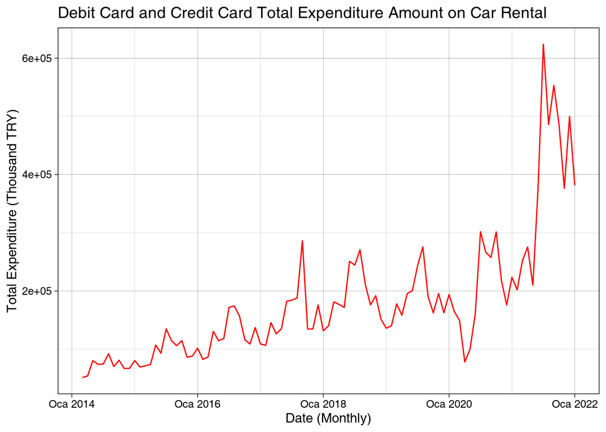

```r
ggplot(ExpendCarRental, aes(Date, Amount)) +
  geom_line(data = ExpendCarRental, color="red", linetype = "solid") +
   ggtitle("Debit Card and Credit Card Total Expenditure Amount on Car Rental") +
    xlab("Date (Monthly)") + ylab("Total Expenditure (Thousand TRY)") +
    theme_linedraw()
```